# Assignment 2 – SQL and R

Matthew Lucich

```r
library(DBI)
library(dplyr)
library(stringr)
```

### Overview and Workflow

To develop a common pipeline: data was extracted from a CSV, loaded into multiple MySQL database tables, and briefly explored for high-level insights. First, consideration was put into the database schema, which ended up including three tables in order to enforce table normalization. Next, an AWS RDS database was created and connected to. Then, tables were created, while taking care to properly specify rules regarding nulls, data types, and value lengths. The data was inserted into the tables after manipulation that converted the data from a CSV, to data frames, to SQL. Lastly, the data was explored for insights, which will be discussed further in the conclusion.

### Database Schema

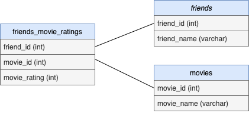

Movie Rating Database Schema

### Connecting to AWS RDS database

```r
# External database (optional)
con <- DBI::dbConnect(RMySQL::MySQL(),
  host = "cuny.cmmkrxiood0c.us-east-2.rds.amazonaws.com",
  port = 3306,
  user = "admin",
  password = rstudioapi::askForPassword("Enter password")
)

# Or replicate with SQLite
#con = dbConnect(RSQLite::SQLite(), dbname = "cunysps")

# (skip if using SQLite) Create database
dbSendStatement(con, "CREATE DATABASE IF NOT EXISTS cunysps;")

# (skip if using SQLite) Select database
dbSendStatement(con, "USE cunysps;")
```

### Create tables

```r
# Create friends table
dbSendStatement(con, "CREATE TABLE IF NOT EXISTS friends
  (
   friend_id        INT(3) PRIMARY KEY, -- Autoincrement
   friend_name      VARCHAR(50) NOT NULL
  )")

# Create movies table
dbSendStatement(con, "CREATE TABLE IF NOT EXISTS movies
  (
   movie_id         INT(3) PRIMARY KEY, -- Autoincrement
   movie_name       VARCHAR(100) NOT NULL
  )")

# Create friends_movie_ratings table
dbSendStatement(con, "CREATE TABLE IF NOT EXISTS friends_movie_ratings
  (
   friend_id        INT(3) NOT NULL,
   movie_id             INT(3) NOT NULL,
   movie_rating     INT(1) NULL
  )")
```

### Insert Values

```r
df_survey <- read.csv("friends_movie_ratings.csv")

# Subset of data for friends table, add friend_id column
df_friends <- select(df_survey, friend_name)
df_friends <- distinct(df_friends, friend_name)
df_friends$friend_id <- seq.int(nrow(df_friends))

# Subset of data for movies table, add movie_id column
df_movies <- select(df_survey, movie_name)
df_movies <- distinct(df_movies, movie_name)
df_movies$movie_id <- seq.int(nrow(df_movies))

# Subset of data for friends_movie_ratings table, join dfs for IDs
df_ratings <- left_join(df_survey, df_friends, by = "friend_name")
df_ratings <- left_join(df_ratings, df_movies, by = "movie_name")
df_ratings <- select(df_ratings, friend_id, movie_id, movie_rating)

# Insert values into friends table
friends_values <- paste0(apply(df_friends, 1,
                       function(x) paste0("(", "'", paste0(x, collapse = "', "), ")")),
                       collapse = ", ")

dbSendStatement(con, paste0("INSERT INTO friends (friend_name, friend_id) VALUES ",
                            friends_values, ";"))

# Insert values into movies table
movies_values <- paste0(apply(df_movies, 1,
                       function(x) paste0("(", "'", paste0(x, collapse = "', "), ")")),
                       collapse = ", ")

dbSendStatement(con, paste0("INSERT INTO movies (movie_name, movie_id) VALUES ",
                            movies_values, ";"))

# Insert values into movie_rating_values table
movie_rating_values <- paste0(apply(df_ratings, 1,
                       function(x) paste0("(", "", paste0(x, collapse = ", "), ")")),
                       collapse = ", ")
movie_rating_values <- str_replace_all(movie_rating_values, "NA", "null")

dbSendStatement(con, paste0("INSERT INTO friends_movie_ratings
                            (friend_id, movie_id, movie_rating) VALUES ",
                            movie_rating_values, ";"))
```

### Query tables

```r
# Query all columns from each table
dbGetQuery(con, "SELECT * FROM friends;")
dbGetQuery(con, "SELECT * FROM movies;")
dbGetQuery(con, "SELECT * FROM friends_movie_ratings;")

# (skip if using SQLite) View standardized ratings
dbGetQuery(con, "WITH
                ratings_stats AS (SELECT avg(movie_rating) as mean,
                                         std(movie_rating) as sd
                                  FROM friends_movie_ratings)
                SELECT  friend_id,
                        movie_id,
                        movie_rating,
                          abs(movie_rating - ratings_stats.mean) /
                            ratings_stats.sd as rating_z_score
                FROM friends_movie_ratings JOIN ratings_stats;")

# View all our data columns together
dbGetQuery(con, "SELECT friends_movie_ratings.friend_id, friends.friend_name,
                        friends_movie_ratings.movie_id, movies.movie_name,
                        friends_movie_ratings.movie_rating
                FROM friends_movie_ratings
                JOIN friends ON friends_movie_ratings.friend_id=friends.friend_id
                JOIN movies ON friends_movie_ratings.movie_id=movies.movie_id;")

# View only friend_name, movie_name, and movie_rating
dbGetQuery(con, "SELECT friends.friend_name,
                        movies.movie_name,
                        friends_movie_ratings.movie_rating
                FROM friends_movie_ratings
                JOIN friends ON friends_movie_ratings.friend_id=friends.friend_id
                JOIN movies ON friends_movie_ratings.movie_id=movies.movie_id;")
```

### Write to data frame and CSV

```r
# Write SQL query to data frame
df_fmr <- data.frame(dbGetQuery(con, "SELECT friends_movie_ratings.friend_id,
                        friends.friend_name,
                        friends_movie_ratings.movie_id, movies.movie_name,
                        friends_movie_ratings.movie_rating
                FROM friends_movie_ratings
                JOIN friends ON friends_movie_ratings.friend_id=friends.friend_id
                JOIN movies ON friends_movie_ratings.movie_id=movies.movie_id;"))

# Disconnect from database
dbDisconnect(con)

# Preview the data frame
head(df_fmr, 20)

# Find the movie with the highest avg. rating
df_fmr_no_nas <- df_fmr %>% filter(!is.na(movie_rating))
df_avg_rating <- aggregate(movie_rating ~ movie_id, df_fmr_no_nas, mean)
top_rated_movie <- df_avg_rating[order(-df_avg_rating$movie_rating),][1:1,]
top_rated_movie_id <- select(top_rated_movie, movie_id)[1,]

# See if any of my friends have not seen the top rated movie and if so, recommend it
df_fmr_only_nas <- df_fmr %>% filter(is.na(movie_rating) & movie_id == top_rated_movie_id)
df_fmr_only_nas
```

[output not shown]

### Conclusions and Recommendations

This pipeline, while fairly scalable, would likely need to be tweaked to better automate the process of loading CSV data into SQL tables. Currently, manual attention needs to be put into the data manipulation tasks to account for data type (e.g. int, str). Some built-in DBI functions handle the conversions for you, but if utilized, force you to give up some control of the table schema. Ultimately, decided to use the more explicit SQL insertions over the abstracted dbWriteTable function to demonstrate understanding of SQL.

In regards to recommendations, the approach was to calculate the average rating for each movie, then determine if any friends have not seen the top rated movie. It turns out two friends, Rachel Jennings and Tom Phillip, did not see the top movie, Parasite. Therefore, Parasite will be recommended to them.

This work is licensed under a [Creative Commons Attribution-ShareAlike 4.0 International License](http://creativecommons.org/licenses/by-sa/4.0/).